# Lab 12: Regular Expression (part 1)

Stat 133, Spring 2022

### Learning Objectives

> - Work with the package `"stringr"`
> - String manipulation
> - Intro to regular expressions

### General Instructions

- Write your descriptions, explanations, and code in an `Rmd` (R markdown) file.
- Name this file as `lab12-first-last.Rmd`, where `first` and `last` are your first and last names (e.g. `lab12-gaston-sanchez.Rmd`).
- Knit your `Rmd` file as an html document (default option).
- Submit your `Rmd` and `html` files to bCourses, in the corresponding lab assignment.

```
# required packages
library(tidyverse)
library(XML)
```

## Introduction to Regular Expressions (Regex)

**Regular expression** also known as **Regex** is a tool for describing patterns in strings. While R provides a set of built-in functions for regex pattern matching, I recommend that you use functions from `"stringr"` (part of the *tidyverse*), which in turn is based on `"stringi"`.

### Main `"stringr"` functions for regex

The goal of this lab is for you to get a first contact with the most common regex functions in `"stringr"` (see below), and to play a little bit with matching basic regex patterns (e.g. literal characters, escaping metacharacters, using character sets, character classes, anchors, and quantifiers).

- `str_match()`
- `str_detect()`
- `str_extract()`
- `str_locate()`
- `str_sub()`
- `str_split()`
- `str_remove()`
- `str_replace()`

### Some common regex patterns

Here’s a table with some of the common regex patterns:

**Lieteral Characters, Wildcard, and Anchors**

| Pattern | Description |
| --- | --- |
| `abc` | letters |
| `123` | digits |
| `.` | any chracter |
| `\\.` | literal dot |
| `^a` | starts with *a* |
| `b$` | ends with *b* |

**Character Sets and Ranges**

| Pattern | Description |
| --- | --- |
| `[abd]` | only a, b, or c |
| `[^abc]` | not a, b, nor c |
| `[a-z]` | characters a to z |
| `[A-Z]` | characters A to Z |
| `[0-9]` | numbers 0 to 9 |

**POSIX Classes**

[output not shown]

**Abbreviated Character classes**

| Pattern | Description |
| --- | --- |
| `\\d` | any digit |
| `\\D` | any Non-digit |
| `\\w` | any alphanumeric character |
| `\\W` | any non-alphanumeric character |
| `\\s` | any whitespace |
| `\\S` | any Non-whitespace |

**Repetition and Quantifiers**

| Pattern | Description |
| --- | --- |
| `a{m}` | *m* repetitions of `"a"` |
| `a{m,n}` | *m* to *n* repetitions of `"a"` |
| `a*` | zero or more repetitions of `"a"` |
| `a+` | one or more repetitions of `"a"` |
| `a?` | optional character `"a"` |

## 1) Data

You will be working with the data set for the *Women’s discus throw world record progression*, available in wikipedia:

https://en.wikipedia.org/wiki/Women%27s_discus_throw_world_record_progression

The following code downloads the html file of the wikipedia page to your working directory:

```r
# Download a copy of the HTML file,
wiki = "https://en.wikipedia.org/wiki/"
women_discus = "Women%27s_discus_throw_world_record_progression"
wiki_men_discus = paste0(wiki, women_discus)
download.file(wiki_men_discus, "women-discus-throw.html")
```

Assuming that you’ve downloaded the html content in the file `women-discus-throw.html`, run the following command to extract (i.e. scrape) the contents of the HTML table into an R data.frame

```r
# extract HTML table into a data.frame
tables = readHTMLTable("women-discus-throw.html", header = TRUE)
dat = tables[[2]]
dim(dat)
```

```
## [1] 57  4
```

### Data Cleaning

The main goal is to clean the downloaded data frame in order to produce a tidy data frame via string manipulations with regex. More specifically, the *clean* data frame will have the following columns:

- `mark` (in meters)
- `first_name` (first name of athlete)
- `last_name` (last name of athlete)
- `initials` (name initials)
- `country` (name of country abbreviation)
- `day` (number of day)
- `month` (name of month)
- `year` (number of year)

## 2) Extracting Mark (in meters)

The column `Mark` contains a character string with the record expressed both in meters and feet-inches. We want to extract only the value associated to meters.

My suggestion is to always start small. In this case, you can get a subset of values on which to test your regex patterns:

```r
tmp <- head(dat$Mark)
tmp
```

```
## [1] "24.90 m (.mw-parser-output .frac{white-space:nowrap}.mw-parser-output .frac .num,.mw-parser-output .frac .den{font-size:80%;line-height:0;vertical-align:super}.mw-parser-output .frac .den{vertical-align:sub}.mw-parser-output .sr-only{border:0;clip:rect(0,0,0,0);height:1px;margin:-1px;overflo…
## [2] "26.62 m (87 ft 4 in)"
## [3] "27.39 m (89 ft 10+1⁄4 in)"
## [4] "27.70 m (90 ft 10+1⁄2 in)"
## [5] "28.325 m (92 ft 11 in)"
## [6] "30.225 m (99 ft 1+3⁄4 in)"
```

With the values in `tmp`, you can match the numeric values of meters with a pattern that matches a string **beginning** with two digits, followed by a dot `"."`, followed by two more digits

```r
str_extract(tmp, "^[0-9][0-9]\\.[0-9][0-9]")
```

```
## [1] "24.90" "26.62" "27.39" "27.70" "28.32" "30.22"
```

### 2.1) Your Turn: Meters

1. Use `str_extract()` with a pattern that matches a string **beginning** with two digits, followed by a dot `"."`, followed by two more digits. Come up with three different regex patterns that meet these criteria.

```r
str_extract(tmp, "^[:digit:][:digit:]\\.[:digit:][:digit:]")
```

```
## [1] "24.90" "26.62" "27.39" "27.70" "28.32" "30.22"
```

```r
str_extract(tmp, "^\\d+\\d\\.\\d\\d")
```

```
## [1] "24.90" "26.62" "27.39" "27.70" "28.32" "30.22"
```

```r
str_extract(tmp, "^\\d+?\\.[[:digit:]][[:digit:]]")
```

```
## [1] "24.90" "26.62" "27.39" "27.70" "28.32" "30.22"
```

2. Once you have a simple pattern, use it on the entire column `Mark` and get a **numeric vector** `mark`:

```r
mark <- as.numeric(str_extract(dat$`Mark`, "^\\d+\\d\\.\\d\\d"))
mark
```

```
##  [1] 24.90 26.62 27.39 27.70 28.32 30.22 31.15 34.15 38.34 39.18 39.62 40.34
## [13] 40.39 40.84 42.43 43.08 43.79 44.34 44.76 45.53 46.10 47.12 48.31 53.25
## [25] 53.37 53.61 57.04 57.15 57.43 58.06 58.98 59.29 59.70 61.26 61.64 62.54
## [37] 62.70 63.96 64.22 64.88 65.42 65.48 66.76 67.32 67.44 67.58 69.48 69.90
## [49] 70.20 70.50 70.72 71.50 71.80 73.26 73.36 74.56 76.80
```

## 3) Extracting Athlete Name

The second task involves extracting the first and last names of the athletes. If you inspect the column `Athlete`, you will see that all its values are formed with the first name, the last name, and the country inside parenthesis:

```r
ath <- head(dat$Athlete)
ath
```

```
## [1] " Lilli Henoch (GER)"     " Lilli Henoch (GER)"
## [3] " Yvonne Tembouret (FRA)" " Lucie Petit (FRA)"
## [5] " Lisette Petré (BEL)"    " Lucienne Velu (FRA)"
```

### 3.1) Your Turn: play with `ath`

1. Work with the sample vector `ath` and try to `str_extract()` the first name. You can experiment with the *word* pattern `"\\w+"` (i.e. one or more alphanumeric characters):

```r
str_extract(ath, "\\w+")
```

```
## [1] "Lilli"    "Lilli"    "Yvonne"   "Lucie"    "Lisette"  "Lucienne"
```

2. Now use the patterns *whitespace* `"\\s"` and *word* `"\\w+"` to attempt extracting the athlete’s last name; to remove the extra matched space you can use `str_trim()`

```r
str_trim(str_extract(str_trim(ath), "\\s\\w+"))
```

```
## [1] "Henoch"    "Henoch"    "Tembouret" "Petit"     "Petré"     "Velu"
```

3. Once you are done working with `ath`, use your code to extract the first and last names of all athletes; use vectors `first_name` and `last_name` for this purpose:

```r
first_name <- str_extract(dat$`Athlete`, "\\w+")
last_name <- str_trim(str_extract(str_trim(dat$`Athlete`), "\\s\\w+"))

first_name
```

```
##  [1] "Lilli"     "Lilli"     "Yvonne"    "Lucie"     "Lisette"   "Lucienne"
##  [7] "Maria"     "Halina"    "Milly"     "Halina"    "Halina"    "Jadwiga"
## [13] "Jadwiga"   "Grete"     "Jadwiga"   "Jadwiga"   "Jadwiga"   "Gisela"
## [19] "Gisela"    "Gisela"    "Gisela"    "Gisela"    "Gisela"    "Nina"
## [25] "Nina"      "Nina"      "Nina"      "Tamara"    "Tamara"    "Tamara"
## [31] "Tamara"    "Tamara"    "Tamara"    "Liesel"    "Christine" "Liesel"
## [37] "Liesel"    "Liesel"    "Faina"     "Faina"     "Faina"     "Faina"
## [43] "Faina"     "Argentina" "Faina"     "Faina"     "Faina"     "Faina"
## [49] "Faina"     "Faina"     "Evelin"    "Evelin"    "Mariya"    "Galina"
## [55] "Irina"     "Zdeňka"    "Gabriele"
```

```r
last_name
```

```
##  [1] "Henoch"     "Henoch"     "Tembouret"  "Petit"      "Petré"
##  [6] "Velu"       "Vidlaková"  "Konopacka"  "Reuter"     "Konopacka"
## [11] "Konopacka"  "Wajs"       "Wajs"       "Heublein"   "Wajs"
## [16] "Wajs"       "Wajs"       "Mauermayer" "Mauermayer" "Mauermayer"
## [21] "Mauermayer" "Mauermayer" "Mauermayer" "Dumbadze"   "Dumbadze"
## [26] "Romashkova" "Dumbadze"   "Press"      "Press"      "Press"
## [31] "Press"      "Press"      "Press"      "Westermann" "Spielberg"
## [36] "Westermann" "Westermann" "Westermann" "Melnik"     "Melnik"
## [41] "Melnik"     "Melnik"     "Melnik"     "Menis"      "Melnik"
## [46] "Melnik"     "Melnik"     "Melnik"     "Melnik"     "Melnik"
## [51] "Jahl"       "Jahl"       "Petkova"    "Savinkova"  "Meszynski"
## [56] "Šilhavá"    "Reinsch"
```

### 3.2) Your Turn: Athlete’s Initials

```r
initials <- paste0(str_extract(first_name, "\\w"), ".", str_extract(last_name, "\\w"))

initials
```

```
##  [1] "L.H" "L.H" "Y.T" "L.P" "L.P" "L.V" "M.V" "H.K" "M.R" "H.K" "H.K" "J.W"
## [13] "J.W" "G.H" "J.W" "J.W" "J.W" "G.M" "G.M" "G.M" "G.M" "G.M" "G.M" "N.D"
## [25] "N.D" "N.R" "N.D" "T.P" "T.P" "T.P" "T.P" "T.P" "T.P" "L.W" "C.S" "L.W"
## [37] "L.W" "L.W" "F.M" "F.M" "F.M" "F.M" "F.M" "A.M" "F.M" "F.M" "F.M" "F.M"
## [49] "F.M" "F.M" "E.J" "E.J" "M.P" "G.S" "I.M" "Z.Š" "G.R"
```

## 4) Country

The column **Athlete** also contains the athlete’s country—abbreviated—within parenthesis:

```r
ath <- head(dat$Athlete)
ath
```

```
## [1] " Lilli Henoch (GER)"     " Lilli Henoch (GER)"
## [3] " Yvonne Tembouret (FRA)" " Lucie Petit (FRA)"
## [5] " Lisette Petré (BEL)"    " Lucienne Velu (FRA)"
```

### 4.1) Your Turn: Athlete’s country

1. Use `str_extract()` with a regex pattern that matches the country abbreviation. Come up with three different regex patterns that let you get these characters:

```r
str_extract(ath, "[A-Z]{3}")
```

```
## [1] "GER" "GER" "FRA" "FRA" "BEL" "FRA"
```

```r
str_extract(ath, "[:upper:]{3}")
```

```
## [1] "GER" "GER" "FRA" "FRA" "BEL" "FRA"
```

```r
str_extract(ath, "[A-Z][A-Z][A-Z]")
```

```
## [1] "GER" "GER" "FRA" "FRA" "BEL" "FRA"
```

```r
country <- str_extract(ath, "[:upper:]{3}")
country
```

```
## [1] "GER" "GER" "FRA" "FRA" "BEL" "FRA"
```

## 5) Date

The date values are in the column `Date`:

```r
dts <- head(dat$Date)
dts
```

```
## [1] "1 October 1922"       "8 July 1923"          "23 September 1923[1]"
## [4] "14 July 1924[1]"      "21 July 1924[2][3]"   "14 September 1924[1]"
```

### 5.1) Your Turn: play with `dts`

With the `dts` vector, extract in separate vectors the values of day, month name, and year: you can try using patterns such as `"[0-9]"`, `"\\d+"`, `"\\w+"`:

```r
days <- as.numeric(str_extract(dat$`Date`, "\\d+"))
days
```

```
##  [1]  1  8 23 14 21 14 11 23 22  4 31 15 16 19 19 15 11  2  4 23 29 25 11  8 27
## [26]  9 18 12 15  1 20 18 11  5 26 24 18 27 12  4 31 24  4 23 25 10  7 27 20 24
## [51] 12 10 13 22 17 26  9
```

```r
months <- str_trim(str_extract(dat$`Date`, "\\s\\w+"))
months
```

```
##  [1] "October"   "July"      "September" "July"      "July"      "September"
##  [7] "October"   "May"       "August"    "September" "July"      "May"
## [13] "May"       "Jun"       "June"      "July"      "August"    "June"
## [19] "June"      "June"      "June"      "August"    "July"      "August"
## [25] "May"       "August"    "October"   "September" "July"      "September"
## [31] "September" "May"       "August"    "November"  "May"       "July"
## [37] "June"      "September" "August"    "September" "May"       "June"
## [43] "August"    "September" "May"       "July"      "September" "May"
## [49] "August"    "April"     "August"    "May"       "July"      "May"
## [55] "August"    "August"    "July"
```

```r
years <- as.numeric(str_extract(dat$`Date`, "\\d{4}"))
years
```

```
##  [1] 1922 1923 1923 1924 1924 1924 1925 1926 1926 1927 1928 1932 1932 1932 1932
## [16] 1933 1934 1935 1935 1935 1935 1935 1936 1948 1951 1952 1952 1960 1961 1961
## [31] 1961 1963 1965 1967 1968 1968 1969 1969 1971 1971 1972 1972 1972 1972 1973
## [46] 1973 1973 1974 1975 1976 1978 1980 1980 1983 1984 1984 1988
```

## 6) Clean Data Frame

We are assuming that you have created vectors for all the cleaned components:

- `mark` (in meters)
- `first_name` (first name of athlete)
- `last_name` (last name of athlete)
- `initials` (name initials)
- `day` (number of day)
- `month` (name of month)
- `year` (number of year)

### 6.1) Your Turn: assemble `discus`

Create a data frame `discus` with all the above vectors used as column of this table. Display the `head()` and `tail()` of this table.

```r
discus <- data.frame(mark,
                     first_name,
                     last_name,
                     initials,
                     days,
                     months,
                     years)

head(discus)
```

```
##    mark first_name last_name initials days    months years
## 1 24.90      Lilli    Henoch      L.H    1   October  1922
## 2 26.62      Lilli    Henoch      L.H    8      July  1923
## 3 27.39     Yvonne Tembouret      Y.T   23 September  1923
## 4 27.70      Lucie     Petit      L.P   14      July  1924
## 5 28.32    Lisette     Petré      L.P   21      July  1924
## 6 30.22   Lucienne      Velu      L.V   14 September  1924
```

```r
tail(discus)
```

```
##     mark first_name last_name initials days months years
## 52 71.50     Evelin      Jahl      E.J   10    May  1980
## 53 71.80     Mariya   Petkova      M.P   13   July  1980
## 54 73.26     Galina Savinkova      G.S   22    May  1983
## 55 73.36      Irina Meszynski      I.M   17 August  1984
## 56 74.56     Zdeňka   Šilhavá      Z.Š   26 August  1984
## 57 76.80   Gabriele   Reinsch      G.R    9   July  1988
```

## 7) Your Turn: Timeline graph

Graph a timeline to visualize the progression of world records: use `year` for the x-axis, and `mark` for the y-axis

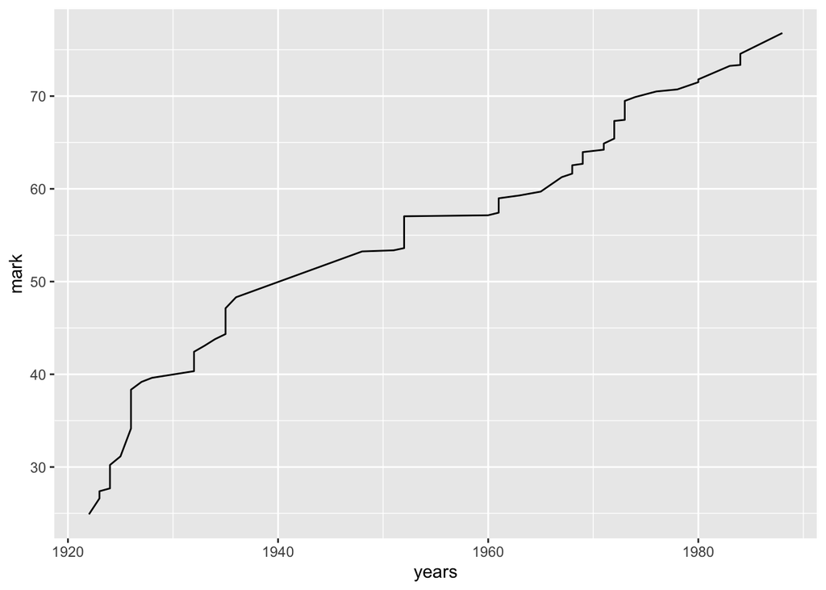

```r
discus %>%
  ggplot(aes(x = years, y = mark)) +
  geom_line()
```

## 8) Your Turn: Challenge

Write code (using a for-loop) to obtain a list `names_month` containing the athlete names, in alphabetical order, that set a world record in each month.

For illustration purposes, here’s what `names_month` should look like for the first three elements. Notice that the last name appears first, followed by a comma, and then the first name. Likewise, the names appear in alphabetical order by last name.

```
$April
[1] "Melnik, Faina"

$May
[1] "Dumbadze, Nina"       "Jahl, Evelin"         "Konopacka, Halina"
[4] "Melnik, Faina"        "Press, Tamara"        "Savinkova, Galina"
[7] "Spielberg, Christine" "Wajs, Jadwiga"

$June
[1] "Mauermayer, Gisela" "Melnik, Faina"      "Wajs, Jadwiga"
[4] "Westermann, Liesel"
```

```r
discus$month[discus$month == "Jun"] <- "June"
month_names <- c("January", "February", "March", "April", "May", "June", "July", "August", "September", "October", "November", "December")
month_fac <- factor(discus$month, levels = month_names)
discus <- arrange(discus, month_fac)
names_month <- list()

for (i in 1:nrow(discus)) {
  names_month[[discus$month[i]]] <- sort(c(names_month[[discus$month[i]]], paste0(discus$last_name[i], ", ", discus$first_name[i])))
}

names_month
```

```
## $April
## [1] "Melnik, Faina"
##
## $May
##  [1] "Dumbadze, Nina"       "Jahl, Evelin"         "Konopacka, Halina"
##  [4] "Melnik, Faina"        "Melnik, Faina"        "Melnik, Faina"
##  [7] "Press, Tamara"        "Savinkova, Galina"    "Spielberg, Christine"
## [10] "Wajs, Jadwiga"        "Wajs, Jadwiga"
##
## $June
## [1] "Heublein, Grete"    "Mauermayer, Gisela" "Mauermayer, Gisela"
## [4] "Mauermayer, Gisela" "Mauermayer, Gisela" "Melnik, Faina"
## [7] "Wajs, Jadwiga"      "Westermann, Liesel"
##
## $July
##  [1] "Henoch, Lilli"      "Konopacka, Halina"  "Mauermayer, Gisela"
##  [4] "Melnik, Faina"      "Petit, Lucie"       "Petkova, Mariya"
##  [7] "Petré, Lisette"     "Press, Tamara"      "Reinsch, Gabriele"
## [10] "Wajs, Jadwiga"      "Westermann, Liesel"
##
## $August
##  [1] "Dumbadze, Nina"     "Jahl, Evelin"       "Mauermayer, Gisela"
##  [4] "Melnik, Faina"      "Melnik, Faina"      "Melnik, Faina"
##  [7] "Meszynski, Irina"   "Press, Tamara"      "Reuter, Milly"
## [10] "Romashkova, Nina"   "Šilhavá, Zdeňka"    "Wajs, Jadwiga"
##
## $September
##  [1] "Konopacka, Halina"  "Melnik, Faina"      "Melnik, Faina"
##  [4] "Menis, Argentina"   "Press, Tamara"      "Press, Tamara"
##  [7] "Press, Tamara"      "Tembouret, Yvonne"  "Velu, Lucienne"
## [10] "Westermann, Liesel"
##
## $October
## [1] "Dumbadze, Nina"   "Henoch, Lilli"    "Vidlaková, Maria"
##
## $November
## [1] "Westermann, Liesel"
```